# Peer Assessment 1

Gyubok Lee

## Data

Our dataset is Activity monitoring data and the variables in this data are such:

- steps: Number of steps taking in a 5-minute interval (missing values are coded as NA)
- date: The date on which the measurement was taken in YYYY-MM-DD format
- interval: Identifier for the 5-minute interval in which measurement was taken

The dataset is stored in a comma-separated-value (CSV) file and there are a total of 17,568 observations in this dataset.

First, I downloaded the file and I will load my data.

## Download, loading and preprocessing the data

Note: I have my working directory on my desktop

```r
setwd("~/Desktop")
fileUrl <- "https://d396qusza40orc.cloudfront.net/repdata%2Fdata%2Factivity.zip"
download.file(fileUrl, destfile="~/Desktop/activity.zip",method="curl")
unzip("~/Desktop/activity.zip")
activity <- read.csv("~/Desktop/activity.csv")
```

## What is mean total number of steps taken per day?

Calculate the total number of steps taken per day

```r
steps <- tapply(activity$steps, activity$date, sum, na.rm=TRUE)
```

Histogram of the total number of steps taken each day

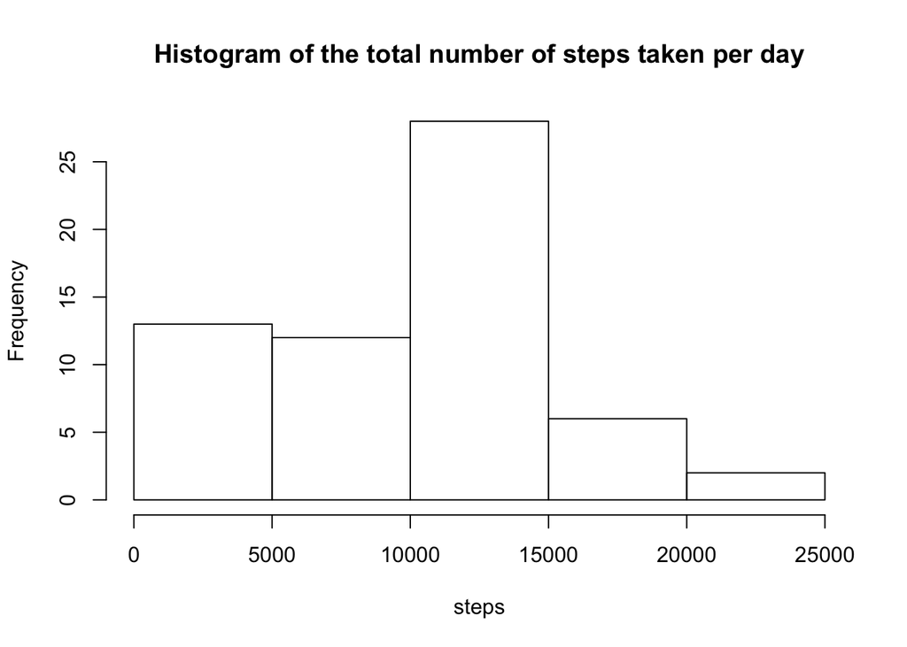

```r
hist(steps, main="Histogram of the total number of steps taken per day")
```

Mean of the total number of steps taken per day

```r
mean(steps)
```

```
## [1] 9354.23
```

Median of the total number of steps taken per day

```r
median(steps)
```

```
## [1] 10395
```

## What is the average daily activity pattern?

Make a time series plot of the 5-minute interval and the average number of steps taken, averaged across all days.

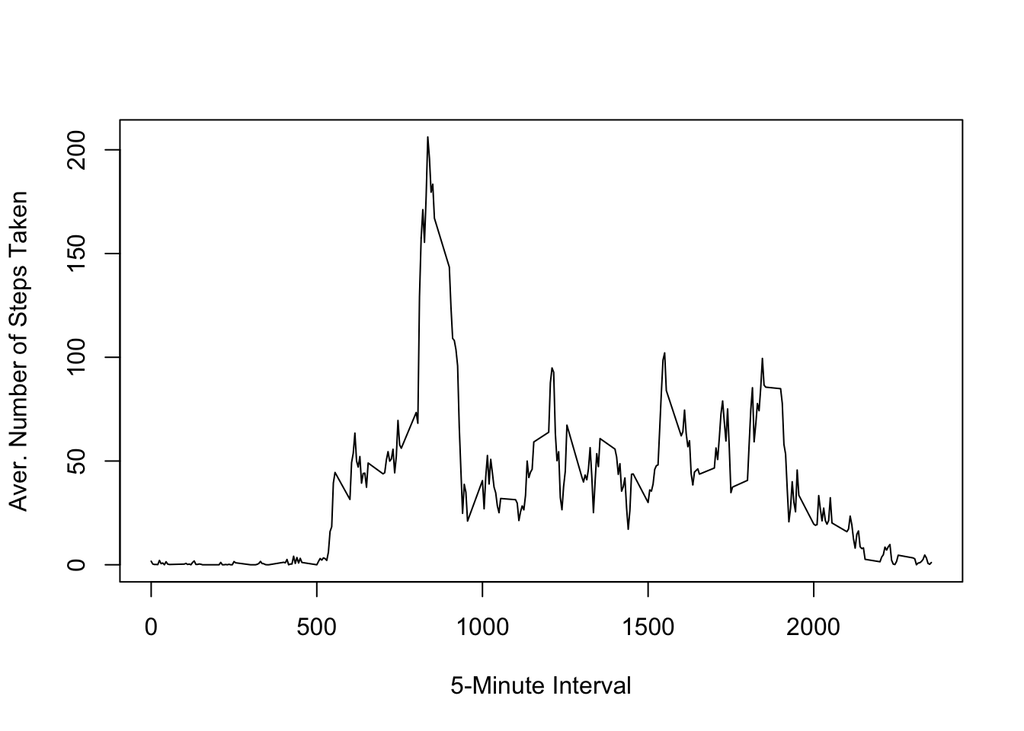

```r
aversteps <- tapply(activity$steps, activity$interval, mean, na.rm=TRUE)
interval <- unique(activity$interval)
plot(interval, aversteps, type="l", xlab= "5-Minute Interval", ylab="Aver. Number of Steps Taken")
```

Which 5-minute interval, on average across all the days in the dataset, contains the maximum number of steps?

```r
interval <- sprintf("%04d", interval)
interval <- format(strptime(interval, format="%H%M"), format = "%H:%M")
interval[which(aversteps==max(aversteps))]
```

```
## [1] "08:35"
```

## Imputing missing values

Calculate and report the total number of missing values in the dataset (i.e. the total number of rows with NAs)

```r
missing <- dim(activity) - dim(activity[complete.cases(activity), ])
missing[1]
```

```
## [1] 2304
```

Devise a strategy for filling in all of the missing values in the dataset. The strategy does not need to be sophisticated. For example, you could use the mean/median for that day, or the mean for that 5-minute interval, etc.

=> It would not be the best way, but I consider using the mean of data as missing values is a quite decent approximation of missing values. Since using the median might treat all missing values zeros, I found using the mean is the most convenient yet efficient way for now.

Create a new dataset that is equal to the original dataset but with the missing data filled in.

```r
activity1 <- activity
activity1[is.na(activity1)] <- (mean(activity$steps, na.rm=TRUE))
```

Make a histogram of the total number of steps taken each day and Calculate and report the mean and median total number of steps taken per day.

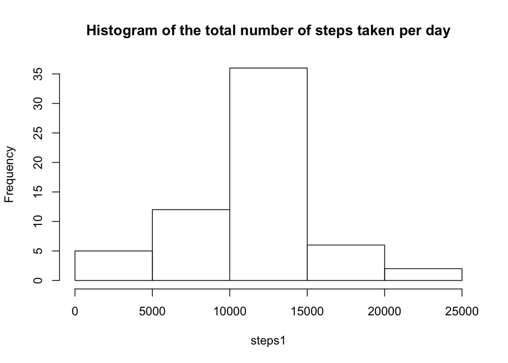

```r
steps1 <- tapply(activity1$steps, activity$date, sum)
hist(steps1, main="Histogram of the total number of steps taken per day")
```

```r
mean(activity$steps, na.rm=TRUE)
```

```
## [1] 37.3826
```

```r
median(activity$steps, na.rm=TRUE)
```

```
## [1] 0
```

```r
mean(activity1$steps, na.rm=TRUE)
```

```
## [1] 37.3826
```

```r
median(activity1$steps, na.rm=TRUE)
```

```
## [1] 0
```

# Are there differences in activity patterns between weekdays and weekends?

Sepereate weekend and weekday data

```r
activity1$date <- weekdays(as.Date(activity$date, "%Y-%m-%d"))

weekend = data.frame()
weekday = data.frame()
for (i in 1:dim(activity1)[1]) {
        if (activity1$date[i]=="Saterday"||activity1$date[i]=="Sunday"){
                weekend <- rbind(weekend, activity1[i,])}
        else {weekday <- rbind(weekday, activity1[i,])}}
```

Declare factors

```r
weekendmean <- tapply(weekend$steps, weekend$interval, mean)
weekdaymean <- tapply(weekday$steps, weekday$interval, mean)
interval <- unique(activity1$interval)
```

Gather all factors in one data to graph

```r
data <- data.frame(c(weekendmean,weekdaymean))
finaldata <- cbind(rep(interval, 2), data, rep(c("weekend","weekday"), each = 288))
colnames(finaldata) <- c("interval", "steps", "day")
```

Graph the data

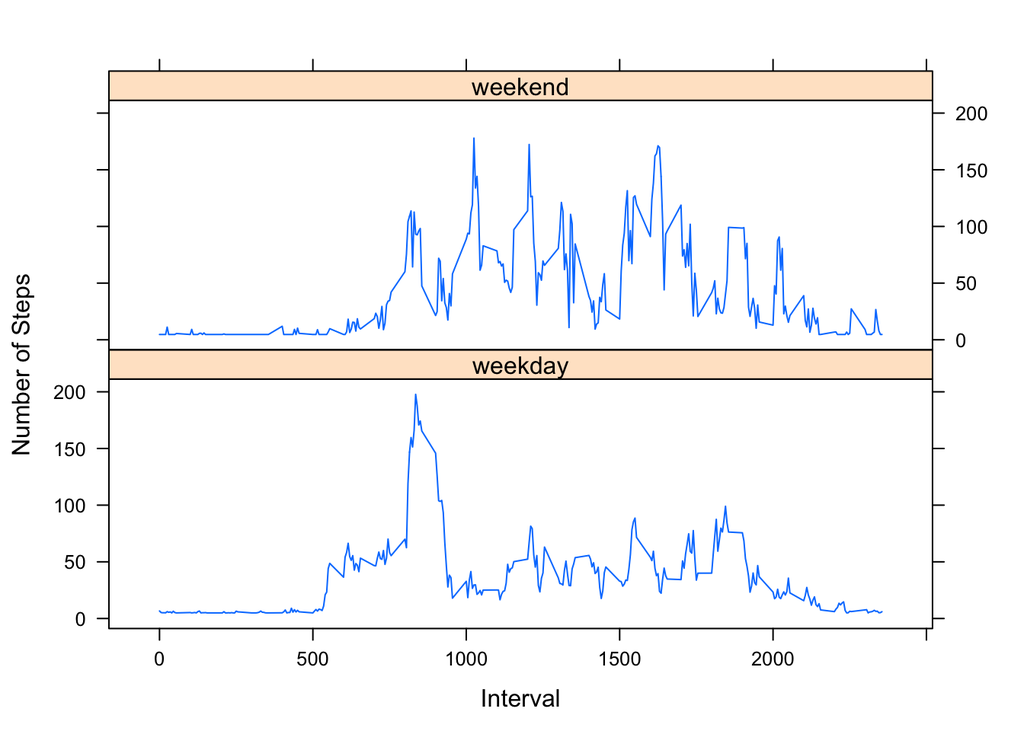

```r
library(lattice)
xyplot(finaldata$steps ~ finaldata$interval |finaldata$day, data = mtcars, pch=19, xlab="Interval",  ylab="Number of Steps",layout=c(1,2),type="l")
```